# Analysis of longitudinal data

### Summary graphs

An easy way of analysing longitudinal data is to use summary methods. From the previous graphs we can clearly see that there is a difference between group 1 and the other two groups but is there a significant difference between groups 2 and 3? Let’s compare the mean weights and standard errors of the three groups. (I installed the package plotrix so that I could count the standard errors more easily since the groups were different in sizes.)

```r
library(dplyr)
library(tidyr)
library(plotrix)

# Summary data with mean and standard error of Weight by Group and Time
RATSS <- RATSL %>%
  group_by(Group, Time) %>%
  summarise(mean = mean(Weight), se = std.error(Weight)) %>%
  ungroup()
# Glimpse the data
glimpse(RATSS)
```

```
## Rows: 33
## Columns: 4
## $ Group <fct> 1, 1, 1, 1, 1, 1, 1, 1, 1, 1, 1, 2, 2, 2, 2, 2, 2, 2, 2, 2, 2, 2…
## $ Time  <int> 1, 8, 15, 22, 29, 36, 43, 44, 50, 57, 64, 1, 8, 15, 22, 29, 36, …
## $ mean  <dbl> 250.625, 255.000, 254.375, 261.875, 264.625, 265.000, 267.375, 2…
## $ se    <dbl> 5.381640, 4.629100, 4.057346, 4.808614, 3.909409, 4.166190, 3.87…
```

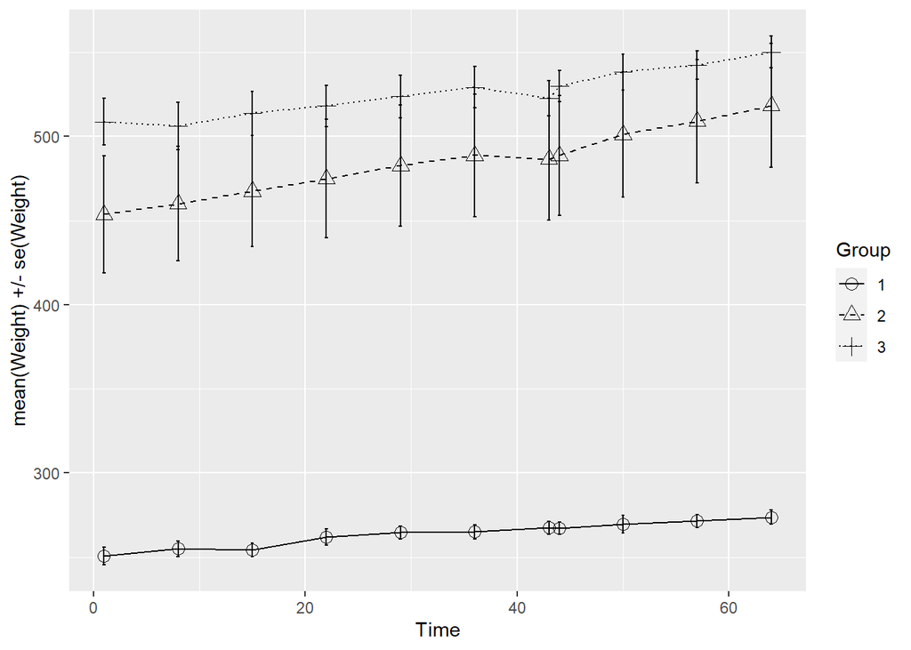

```r
# Plot the mean profiles
library(ggplot2)
ggplot(RATSS, aes(x = Time, y = mean, linetype = Group, shape = Group)) +
  geom_line() +
  scale_linetype_manual(values = c(1,2,3)) +
  geom_point(size=3) +
  scale_shape_manual(values = c(1,2,3)) +
  geom_errorbar(aes(ymin=mean-se, ymax=mean+se, linetype="1"), width=0.3) +
  scale_y_continuous(name = "mean(Weight) +/- se(Weight)")
```

In the above graph we can see that the mean weights of group 2 and 3 seem to differ, although the standard errors are overlapping some and the means comes closer to each other as time passes.  
Let’s compare the mean weights of the groups from the day 8 onwards.

```r
library(dplyr)
library(tidyr)
# Create a summary data by Group and ID with mean as the summary variable (ignoring baseline day 1)
RATSS2 <- RATSL %>%
  filter(Time > 1) %>%
  group_by(Group, ID) %>%
  summarise( mean=mean(Weight) ) %>%
  ungroup()
# Glimpse the data
glimpse(RATSS2)
```

```
## Rows: 16
## Columns: 3
## $ Group <fct> 1, 1, 1, 1, 1, 1, 1, 1, 2, 2, 2, 2, 3, 3, 3, 3
## $ ID    <fct> 1, 2, 3, 4, 5, 6, 7, 8, 9, 10, 11, 12, 13, 14, 15, 16
## $ mean  <dbl> 263.2, 238.9, 261.7, 267.2, 270.9, 276.2, 274.6, 267.5, 443.9, 4…
```

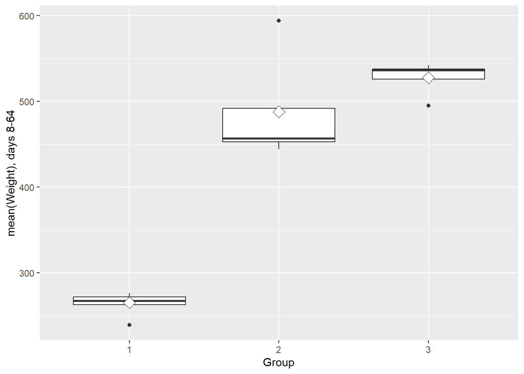

```r
# Draw a boxplot of the mean versus treatment
library(ggplot2)
ggplot(RATSS2, aes(x = Group, y = mean)) +
  geom_boxplot() +
  stat_summary(fun = "mean", geom = "point", shape=23, size=4, fill = "white") +
  scale_y_continuous(name = "mean(Weight), days 8-64")
```

From the box plot (and from the previous graphs of individual rats’ weights) we can see that there is a clear outlier that is considerably heavier than others in the group 2. This outlier makes the mean weights of the group 2 appear too big.There are also two individuals in group 1 and 3 that are smaller than others in their groups. However, their difference to others is not that distinct so I’m going to remove only the one outlier in group 2.

```r
# Create a new data by filtering the outlier and adjust the ggplot code the draw the plot again with the new data
RATSS21 <- RATSS2 %>%  filter(mean < 550)

# Glimpse the data
glimpse(RATSS21)
```

```
## Rows: 15
## Columns: 3
## $ Group <fct> 1, 1, 1, 1, 1, 1, 1, 1, 2, 2, 2, 3, 3, 3, 3
## $ ID    <fct> 1, 2, 3, 4, 5, 6, 7, 8, 9, 10, 11, 13, 14, 15, 16
## $ mean  <dbl> 263.2, 238.9, 261.7, 267.2, 270.9, 276.2, 274.6, 267.5, 443.9, 4…
```

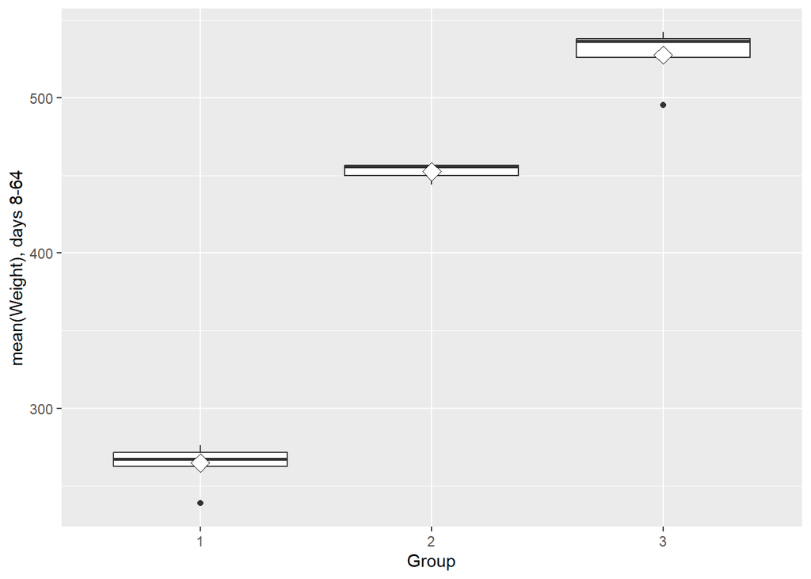

```r
# Draw a boxplot of the mean versus treatment from new data
library(ggplot2)
ggplot(RATSS21, aes(x = Group, y = mean)) +
  geom_boxplot() +
  stat_summary(fun = "mean", geom = "point", shape=23, size=4, fill = "white") +
  scale_y_continuous(name = "mean(Weight), days 8-64")
```

When the outlier in group 2 is removed, we can see that the difference between group 2 and 3 becomes clearer and as before, the group 1 differs clearly from both group 2 and 3. To verify this let’s do oneway ANOVA and pairwise comparisons to the groups. Let’s then fit a linear model to the data with the weight taken prior to the start of study as the baseline covariate and then apply anova again.

```r
library(dplyr)
library(tidyr)

# Compute the analysis of variance
RATSS21.aov <- aov(mean ~ Group, data = RATSS21)
# Summary of the analysis
summary(RATSS21.aov)
```

```
##             Df Sum Sq Mean Sq F value   Pr(>F)
## Group        2 207659  103830   501.8 2.72e-12 ***
## Residuals   12   2483     207
## ---
## Signif. codes:  0 '***' 0.001 '**' 0.01 '*' 0.05 '.' 0.1 ' ' 1
```

```r
# do pairwise comparisons
TukeyHSD(RATSS21.aov)
```

```
##   Tukey multiple comparisons of means
##     95% family-wise confidence level
##
## Fit: aov(formula = mean ~ Group, data = RATSS21)
##
## $Group
##        diff       lwr      upr    p adj
## 2-1 187.375 161.39457 213.3554 0.00e+00
## 3-1 262.475 238.97481 285.9752 0.00e+00
## 3-2  75.100  45.79012 104.4099 4.98e-05
```

```r
# read in the original RATS data
RATS <- read.table("https://raw.githubusercontent.com/KimmoVehkalahti/MABS/master/Examples/data/rats.txt", header = TRUE, sep = '\t')

# Filter out the fattest rat from original data (the outlier in group 2)
RATS2 <- RATS %>%  filter(WD1 < 550)

# Glimpse the original data
glimpse(RATS2)
```

```
## Rows: 15
## Columns: 13
## $ ID    <int> 1, 2, 3, 4, 5, 6, 7, 8, 9, 10, 11, 13, 14, 15, 16
## $ Group <int> 1, 1, 1, 1, 1, 1, 1, 1, 2, 2, 2, 3, 3, 3, 3
## $ WD1   <int> 240, 225, 245, 260, 255, 260, 275, 245, 410, 405, 445, 470, 535,…
## $ WD8   <int> 250, 230, 250, 255, 260, 265, 275, 255, 415, 420, 445, 465, 525,…
## $ WD15  <int> 255, 230, 250, 255, 255, 270, 260, 260, 425, 430, 450, 475, 530,…
## $ WD22  <int> 260, 232, 255, 265, 270, 275, 270, 268, 428, 440, 452, 485, 533,…
## $ WD29  <int> 262, 240, 262, 265, 270, 275, 273, 270, 438, 448, 455, 487, 535,…
## $ WD36  <int> 258, 240, 265, 268, 273, 277, 274, 265, 443, 460, 455, 493, 540,…
## $ WD43  <int> 266, 243, 267, 270, 274, 278, 276, 265, 442, 458, 451, 493, 525,…
## $ WD44  <int> 266, 244, 267, 272, 273, 278, 271, 267, 446, 464, 450, 504, 530,…
## $ WD50  <int> 265, 238, 264, 274, 276, 284, 282, 273, 456, 475, 462, 507, 543,…
## $ WD57  <int> 272, 247, 268, 273, 278, 279, 281, 274, 468, 484, 466, 518, 544,…
## $ WD64  <int> 278, 245, 269, 275, 280, 281, 284, 278, 478, 496, 472, 525, 559,…
```

```r
# Add the baseline from the original data as a new variable to the summary data
RATSS22 <- RATSS21 %>%
  mutate(baseline =RATS2$WD1)

# Fit the linear model with the mean as the response
fit <- lm(mean ~ baseline + Group, data = RATSS22)

# Compute the analysis of variance table for the fitted model with anova()
anova(fit)
```

```
## Analysis of Variance Table
##
## Response: mean
##           Df Sum Sq Mean Sq   F value    Pr(>F)
## baseline   1 207817  207817 2714.9357 1.601e-14 ***
## Group      2   1483     742    9.6878  0.003748 **
## Residuals 11    842      77
## ---
## Signif. codes:  0 '***' 0.001 '**' 0.01 '*' 0.05 '.' 0.1 ' ' 1
```

From the first anova table we can see that there really is significant difference between groups. However, this only tells us that there are significant differences between some of the groups but it doesn’t tell us which pairs of the groups are different. To know this we need to do pairwise comparison. I made a Tukey test and it seems that the differences between all the groups are significant.  
The second ANOVA table tells us weather the coeffiecients in the linear regression model are significant. The baseline is significant at the level of 0,001. This is quite obvious: the start weight of the rat explains its’ later weight very significantly. Also the Group is significant (at level 0,01) meaning that the dietary group also explains the rats’ weight development significantly.

## Linear Mixed Effects Models

Next we leave the rats to themselves and look into the BPRSL data and linear mixed effect models. However, at first we ignore the repeated-measures structure of the data and assume that all the observations are independent of one another. Let’s first plot the data, identifying the observations in each treatment group.

```r
library(dplyr)
library(tidyr)
# Check the dimensions of the data
dim(BPRSL)
```

```
## [1] 360   5
```

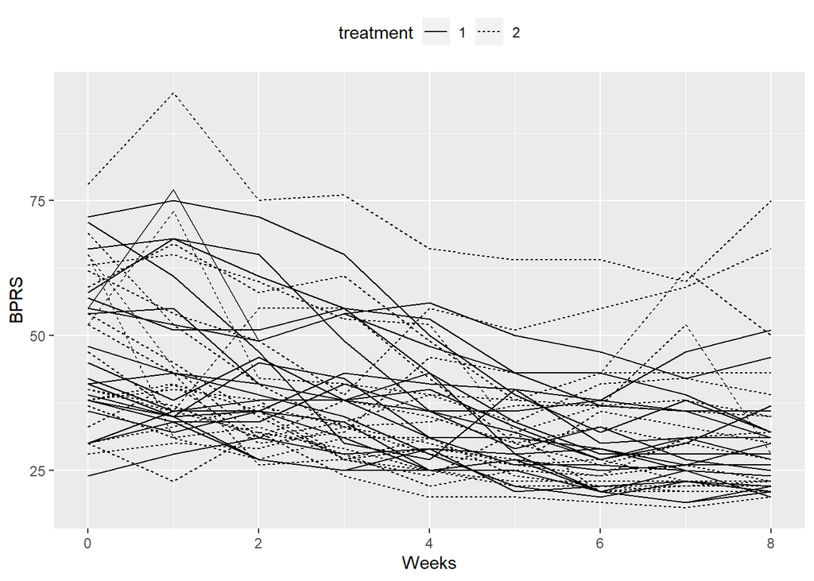

```r
# Plot the BPRSL1 data
library(ggplot2)
ggplot(BPRSL, aes(x = week, y = bprs, group = subject)) +
  geom_line(aes(linetype = treatment)) +
  scale_x_continuous(name = "Weeks") +
  scale_y_continuous(name = "BPRS") +
  theme(legend.position = "top")
```

As we see in the graph the measurements in both treatment group are overlapping and it is hard to tell the difference between the groups.  
Next we will fit a multiple linear regression model with bprs as response and week and treatment as explanatory variables. We will continue to ignore the repeated-measures structure of the data.

```r
# create a regression model BPRS_reg
BPRS_reg <- lm(bprs ~ week + treatment, data = BPRSL)

# print out a summary of the model
summary(BPRS_reg)
```

```
##
## Call:
## lm(formula = bprs ~ week + treatment, data = BPRSL)
##
## Residuals:
##     Min      1Q  Median      3Q     Max
## -22.454  -8.965  -3.196   7.002  50.244
##
## Coefficients:
##             Estimate Std. Error t value Pr(>|t|)
## (Intercept)  46.4539     1.3670  33.982   <2e-16 ***
## week         -2.2704     0.2524  -8.995   <2e-16 ***
## treatment2    0.5722     1.3034   0.439    0.661
## ---
## Signif. codes:  0 '***' 0.001 '**' 0.01 '*' 0.05 '.' 0.1 ' ' 1
##
## Residual standard error: 12.37 on 357 degrees of freedom
## Multiple R-squared:  0.1851, Adjusted R-squared:  0.1806
## F-statistic: 40.55 on 2 and 357 DF,  p-value: < 2.2e-16
```

According to the summary of the linear regression model time (week) is significant at the level of 0,001 but the treatment group is not, meaning that time explains the bprs values significantly but there is no significant difference between the two treatments.

## The Random Intercept Model

The linear regression model assumes independence of the repeated measures of bprs, which is highly unlikely. Let’s now fit the *random intercept model* for the same two explanatory variables: week and treatment. Fitting a random intercept model allows the linear regression fit for each subject to differ in *intercept* from other subjects (Vehkalahti & Everitt, 2019, 177.).

```r
# access library lme4
library(lme4)
# Create a random intercept model
BPRS_ref <- lmer(bprs ~ week + treatment + (1 | subject), data = BPRSL, REML = FALSE)

# Print the summary of the model
summary (BPRS_ref)
```

```
## Linear mixed model fit by maximum likelihood  ['lmerMod']
## Formula: bprs ~ week + treatment + (1 | subject)
##    Data: BPRSL
##
##      AIC      BIC   logLik deviance df.resid
##   2582.9   2602.3  -1286.5   2572.9      355
##
## Scaled residuals:
##      Min       1Q   Median       3Q      Max
## -2.27506 -0.59909 -0.06104  0.44226  3.15835
##
## Random effects:
##  Groups   Name        Variance Std.Dev.
##  subject  (Intercept) 97.39    9.869
##  Residual             54.23    7.364
## Number of obs: 360, groups:  subject, 40
##
## Fixed effects:
##             Estimate Std. Error t value
## (Intercept)  46.4539     2.3521  19.750
## week         -2.2704     0.1503 -15.104
## treatment2    0.5722     3.2159   0.178
##
## Correlation of Fixed Effects:
##            (Intr) week
## week       -0.256
## treatment2 -0.684  0.000
```

The results of the random intercept model is similar to linear regression model. The regression coefficient for week is significant, but again the treatment group is not significant.

### Random intercept and random slope model

Now let’s fit the random intercept and random slope model to the bprs data. Fitting a random intercept and random slope model allows the linear regression fits for each individual to differ in intercept but also in slope. This way it is possible to account for the individual differences in the bprs profiles, but also the effect of time. (Vehkalahti & Everitt, 2019, 179.)

```r
# create a random intercept and random slope model
library(lme4)
BPRS_ref1 <- lmer(bprs ~ week + treatment + (week | subject), data = BPRSL, REML = FALSE)

# print a summary of the model
summary(BPRS_ref1)
```

```
## Linear mixed model fit by maximum likelihood  ['lmerMod']
## Formula: bprs ~ week + treatment + (week | subject)
##    Data: BPRSL
##
##      AIC      BIC   logLik deviance df.resid
##   2523.2   2550.4  -1254.6   2509.2      353
##
## Scaled residuals:
##     Min      1Q  Median      3Q     Max
## -2.4655 -0.5150 -0.0920  0.4347  3.7353
##
## Random effects:
##  Groups   Name        Variance Std.Dev. Corr
##  subject  (Intercept) 167.827  12.955
##           week          2.331   1.527   -0.67
##  Residual              36.747   6.062
## Number of obs: 360, groups:  subject, 40
##
## Fixed effects:
##             Estimate Std. Error t value
## (Intercept)  45.9830     2.6470  17.372
## week         -2.2704     0.2713  -8.370
## treatment2    1.5139     3.1392   0.482
##
## Correlation of Fixed Effects:
##            (Intr) week
## week       -0.545
## treatment2 -0.593  0.000
```

```r
# perform an ANOVA test on the two models
anova(BPRS_ref1, BPRS_ref)
```

```
## Data: BPRSL
## Models:
## BPRS_ref: bprs ~ week + treatment + (1 | subject)
## BPRS_ref1: bprs ~ week + treatment + (week | subject)
##           npar    AIC    BIC  logLik deviance  Chisq Df Pr(>Chisq)
## BPRS_ref     5 2582.9 2602.3 -1286.5   2572.9
## BPRS_ref1    7 2523.2 2550.4 -1254.6   2509.2 63.663  2  1.499e-14 ***
## ---
## Signif. codes:  0 '***' 0.001 '**' 0.01 '*' 0.05 '.' 0.1 ' ' 1
```

Again the results are similar: week is significant, but treatment is not. The ANOVA results for random intercept and random intercept + random slope models indicates that the random intercept + random slope is a better fit for the data, as the chi-square statistics is 63,663 (DF 2) and assosiated p-value is very small and significant at the level of 0,001.

### Random Intercept and Random Slope Model with interaction

Finally, let’s fit a random intercept and slope model that allows for a treatment × week interaction.

```r
# create a random intercept and random slope model with the interaction
library(lme4)
BPRS_ref2 <- lmer(bprs ~ week + treatment + week*treatment +(week | subject), data = BPRSL, REML = FALSE)

# print a summary of the model
summary(BPRS_ref2)
```

```
## Linear mixed model fit by maximum likelihood  ['lmerMod']
## Formula: bprs ~ week + treatment + week * treatment + (week | subject)
##    Data: BPRSL
##
##      AIC      BIC   logLik deviance df.resid
##   2523.5   2554.5  -1253.7   2507.5      352
##
## Scaled residuals:
##     Min      1Q  Median      3Q     Max
## -2.4747 -0.5256 -0.0866  0.4435  3.7884
##
## Random effects:
##  Groups   Name        Variance Std.Dev. Corr
##  subject  (Intercept) 164.204  12.814
##           week          2.203   1.484   -0.66
##  Residual              36.748   6.062
## Number of obs: 360, groups:  subject, 40
##
## Fixed effects:
##                 Estimate Std. Error t value
## (Intercept)      47.8856     2.9840  16.047
## week             -2.6283     0.3752  -7.006
## treatment2       -2.2911     4.2200  -0.543
## week:treatment2   0.7158     0.5306   1.349
##
## Correlation of Fixed Effects:
##             (Intr) week   trtmn2
## week        -0.668
## treatment2  -0.707  0.473
## wek:trtmnt2  0.473 -0.707 -0.668
```

```r
# perform an ANOVA test on the two models
anova(BPRS_ref2, BPRS_ref1)
```

```
## Data: BPRSL
## Models:
## BPRS_ref1: bprs ~ week + treatment + (week | subject)
## BPRS_ref2: bprs ~ week + treatment + week * treatment + (week | subject)
##           npar    AIC    BIC  logLik deviance Chisq Df Pr(>Chisq)
## BPRS_ref1    7 2523.2 2550.4 -1254.6   2509.2
## BPRS_ref2    8 2523.5 2554.6 -1253.7   2507.5  1.78  1     0.1821
```

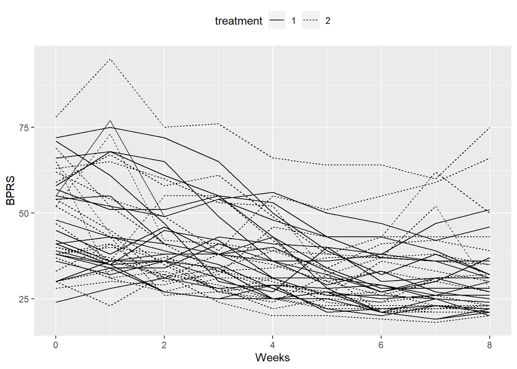

```r
# draw the plot of BPRSL with the observed bprs values
ggplot(BPRSL, aes(x = week, y = bprs, group = subject)) +
  geom_line(aes(linetype = treatment)) +
  scale_x_continuous(name = "Weeks") +
  scale_y_continuous(name = "BPRS") +
  theme(legend.position = "top")
```

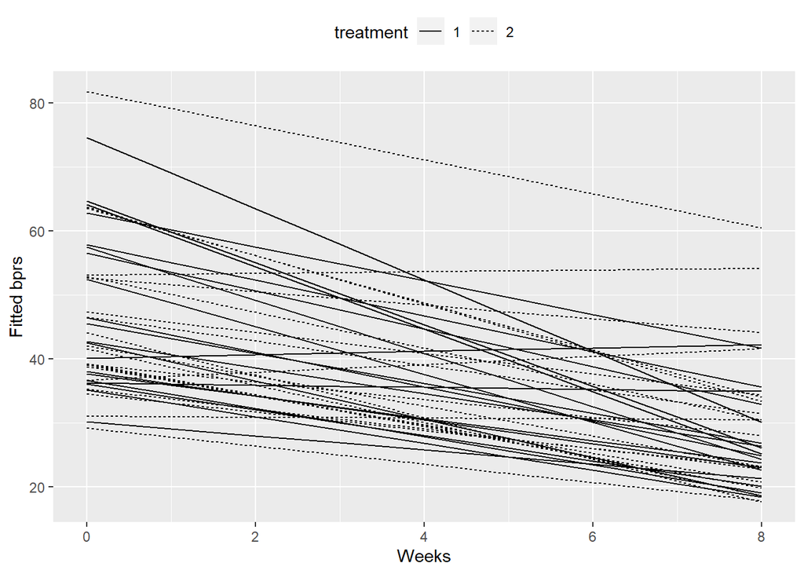

```r
# Create a vector of the fitted values
Fitted <- fitted(BPRS_ref2)

library(dplyr)
library(tidyr)
# Create a new column fitted to BPRSL
BPRSL <- mutate(BPRSL, Fitted = Fitted)

# draw the plot of BPRSL with the Fitted values of bprs
library(ggplot2)
ggplot(BPRSL, aes(x = week, y = Fitted, group = subject)) +
  geom_line(aes(linetype = treatment)) +
  scale_x_continuous(name = "Weeks") +
  scale_y_continuous(name = "Fitted bprs") +
  theme(legend.position = "top")
```

The model with interaction doesn’t fit the data significantly better than the model with just random intercept and random slope. The interaction of weeks and treatment isn’t significant. From the graphs we can see that the model roughly fits the data. There are, however, so much weekly variation in the bprs values, that no linear model is going to fit perfectly.

## References

Vehkalahti, K. & Everitt, B. S. (2019). *Multivariate Analysis for the Behavioral Sciences* , Second Edition. Chapman and Hall/CRC, Boca Raton, Florida, USA.